# Attraktivität von Universitäten im Vergleich

Antonio Amaddio

6/23/2022

```r
knitr::opts_chunk$set(echo = FALSE)
# Daten einlesen
library(readr)
#raw_data <- read_csv("data_project_935154_2022_06_22.csv")
raw_data <- read_delim("data_project_935154_2022_06_23_perfect_data.csv",
    delim = ";", escape_double = FALSE, trim_ws = TRUE)
# Uni: A; Auswertung: auto; Zeit & Ort: flexibel; Bedingung: 1
study_data <- data.frame(id = raw_data[["lfdn"]])
study_data$intension_to_apply_uni_a <- rowMeans(raw_data[,c("v_30", "v_31", "v_32", "v_33", "v_34")])
study_data$attraction_uni_a <- rowMeans(raw_data[,c("v_55", "v_56", "v_57", "v_58", "v_59", "v_60", "v_61", "v_62", "v_63", "v_64" )])

# Uni: B; Auswertung: human; Zeit & Ort: fix; Bedingung: 4
study_data$intension_to_apply_uni_b <- rowMeans(raw_data[,c("v_45", "v_46", "v_47", "v_48", "v_49")])
study_data$attraction_uni_b <- rowMeans(raw_data[,c("v_65", "v_66", "v_67", "v_68", "v_69", "v_70", "v_71", "v_72", "v_73", "v_74")])

# Uni: C; Auswertung: auto; Zeit & Ort: fix; Bedingung: 2
study_data$intension_to_apply_uni_c <- rowMeans(raw_data[,c("v_130","v_131","v_132","v_133","v_134")])
study_data$attraction_uni_c <- rowMeans(raw_data[,c("v_110", "v_111", "v_112", "v_113", "v_114", "v_115", "v_116", "v_117", "v_118", "v_119")])

# Uni: D; Auswertung: human; Zeit & Ort: flexibel; Bedingung: 3
study_data$intension_to_apply_uni_d <- rowMeans(raw_data[,c("v_105", "v_106", "v_107", "v_108", "v_109" )])
study_data$attraction_uni_d <- rowMeans(raw_data[,c("v_120", "v_121", "v_122", "v_123", "v_124", "v_125", "v_126", "v_127", "v_128", "v_129")])

# Aggreggierte Mittelwerte nach Gruppen Auswertung: human = 0; auto = 1
study_data$mean_intension_to_apply_uni_human_assessment <- rowMeans(cbind(study_data$intension_to_apply_uni_b, study_data$intension_to_apply_uni_d))
study_data$mean_intension_to_apply_uni_auto_assessment <- rowMeans(cbind(study_data$intension_to_apply_uni_a, study_data$intension_to_apply_uni_c))
study_data$mean_attraction_uni_human_assessment <- rowMeans(cbind(study_data$attraction_uni_b, study_data$attraction_apply_uni_d))
study_data$mean_attraction_uni_auto_assessment <- rowMeans(cbind(study_data$attraction_uni_a, study_data$attraction_apply_uni_c))
# "" nach zeitlicher / oertlicher Pruefungsmodalitaet: flexible = 0; fix = 1
study_data$mean_intension_to_apply_uni_flexible_assessment <- rowMeans(cbind(study_data$intension_to_apply_uni_a, study_data$intension_to_apply_uni_d))
study_data$mean_intension_to_apply_uni_fixed_assessment <- rowMeans(cbind(study_data$intension_to_apply_uni_b, study_data$intension_to_apply_uni_c))
study_data$mean_attraction_uni_flexible_assessment <- rowMeans(cbind(study_data$attraction_uni_a, study_data$attraction_apply_uni_d))
study_data$mean_attraction_uni_fixed_assessment <- rowMeans(cbind(study_data$attraction_uni_b, study_data$attraction_apply_uni_c))

study_data$technical_affinity1 <- rowMeans(raw_data[,c("v_16", "v_17", "v_18", "v_19", "v_20" )])
study_data$technical_affinity2 <- rowMeans(raw_data[,c("v_35", "v_36", "v_37", "v_38")])
study_data$mean_technical_affinity <- rowMeans(cbind(study_data$technical_affinity1, study_data$technical_affinity2))

# todo: noch richtig in einen Faktor konvertieren
# oder als kontinuierliche Variable behalten?
# https://www.datacamp.com/tutorial/factor-levels-r
study_data$age <- raw_data[["v_76"]]

# todo: noch richtig in einen Faktor konvertieren
# https://www.datacamp.com/tutorial/factor-levels-r
study_data$gender <- factor(raw_data[["v_79"]])
# levels(study_data$gender) <- c("w","m","o","na")

# todo: noch richtig in einen Faktor konvertieren
# https://www.datacamp.com/tutorial/factor-levels-r
study_data$course_of_study <- factor(raw_data[["v_135"]])

# weites Datenformat in langes Datenformat ändern
# siehe: http://www.cookbook-r.com/Manipulating_data/Converting_data_between_wide_and_long_format/
summary(study_data)
```

```
##        id        intension_to_apply_uni_a attraction_uni_a
##  Min.   : 1.00   Min.   :1.20             Min.   :1.50
##  1st Qu.:13.25   1st Qu.:1.80             1st Qu.:1.90
##  Median :25.50   Median :2.00             Median :1.90
##  Mean   :25.50   Mean   :1.96             Mean   :1.98
##  3rd Qu.:37.75   3rd Qu.:2.20             3rd Qu.:2.10
##  Max.   :50.00   Max.   :2.60             Max.   :2.50
##  intension_to_apply_uni_b attraction_uni_b intension_to_apply_uni_c
##  Min.   :3.200            Min.   :3.40     Min.   :1.200
##  1st Qu.:3.800            1st Qu.:4.00     1st Qu.:1.800
##  Median :4.000            Median :4.10     Median :2.000
##  Mean   :4.024            Mean   :4.11     Mean   :2.056
##  3rd Qu.:4.400            3rd Qu.:4.30     3rd Qu.:2.400
##  Max.   :5.000            Max.   :4.50     Max.   :2.800
##  attraction_uni_c intension_to_apply_uni_d attraction_uni_d
##  Min.   :1.200    Min.   :3.000            Min.   :3.500
##  1st Qu.:1.800    1st Qu.:3.800            1st Qu.:3.800
##  Median :2.000    Median :4.000            Median :4.050
##  Mean   :1.938    Mean   :3.948            Mean   :4.046
##  3rd Qu.:2.100    3rd Qu.:4.200            3rd Qu.:4.200
##  Max.   :2.400    Max.   :4.800            Max.   :4.800
##  mean_intension_to_apply_uni_human_assessment
##  Min.   :3.300
##  1st Qu.:3.800
##  Median :4.000
##  Mean   :3.986
##  3rd Qu.:4.200
##  Max.   :4.600
##  mean_intension_to_apply_uni_auto_assessment
##  Min.   :1.500
##  1st Qu.:1.800
##  Median :2.000
##  Mean   :2.008
##  3rd Qu.:2.175
##  Max.   :2.400
##  mean_attraction_uni_human_assessment mean_attraction_uni_auto_assessment
##  Min.   :3.40                         Min.   :1.50
##  1st Qu.:4.00                         1st Qu.:1.90
##  Median :4.10                         Median :1.90
##  Mean   :4.11                         Mean   :1.98
```

[output cut: 22 more lines]

```
##  Max.   :2.50                            Max.   :4.50
##  technical_affinity1 technical_affinity2 mean_technical_affinity
##  Min.   :1.400       Min.   :1.25        Min.   :1.550
##  1st Qu.:1.600       1st Qu.:1.75        1st Qu.:1.806
##  Median :2.000       Median :2.00        Median :1.988
##  Mean   :1.964       Mean   :2.04        Mean   :2.002
##  3rd Qu.:2.200       3rd Qu.:2.25        3rd Qu.:2.175
##  Max.   :2.800       Max.   :2.75        Max.   :2.650
##       age        gender course_of_study
##  Min.   :18.00   1:10   2:50
##  1st Qu.:22.00   2:21
##  Median :25.50   3:11
##  Mean   :25.90   4: 8
##  3rd Qu.:30.75
##  Max.   :35.00
```

```r
# add dummy
library(tidyr)
#### Erstelle die aggregierten Werte für die abhängigen Variablen für die Prüfungsauswertung (H1)
####### Bewerbungsabsicht (intension)
assessment_data <- gather(study_data, human_auto, intension, mean_intension_to_apply_uni_human_assessment:mean_intension_to_apply_uni_auto_assessment, factor_key=TRUE)
# Rename factor names from "mean_intension_to_apply_uni_human_assessment" and "mean_intension_to_apply_uni_auto_assessment" to "first" and "second"
levels(assessment_data$human_auto)[levels(assessment_data$human_auto)=="mean_intension_to_apply_uni_human_assessment"] <- "human"
levels(assessment_data$human_auto)[levels(assessment_data$human_auto)=="mean_intension_to_apply_uni_auto_assessment"] <- "auto"

####### Attraktivität (attraction)
attraction_data_long <- gather(study_data, human_auto, attraction, mean_attraction_uni_human_assessment:mean_attraction_uni_auto_assessment, factor_key=TRUE)

assessment_data$attraction <- attraction_data_long$attraction
assessment_data$mean_attraction_uni_human_assessment <- attraction_data_long$mean_attraction_uni_human_assessment
assessment_data$mean_attraction_uni_auto_assessment <- attraction_data_long$mean_attraction_uni_auto_assessment
rm(attraction_data_long) # Hilfsvariable löschen

#### Erstelle die aggregierten Werte für die abhängigen Variablen für die Prüfungsmodalität (H2)
modality_data <- gather(study_data, flexible_fixed, intension, mean_intension_to_apply_uni_flexible_assessment:mean_intension_to_apply_uni_fixed_assessment, factor_key=TRUE)
# Rename factor names from "mean_intension_to_apply_uni_human_assessment" and "mean_intension_to_apply_uni_auto_assessment" to "first" and "second"
levels(modality_data$flexible_fixed)[levels(modality_data$flexible_fixed)=="mean_intension_to_apply_uni_flexible_assessment"] <- "flexible"
levels(modality_data$flexible_fixed)[levels(modality_data$flexible_fixed)=="mean_intension_to_apply_uni_fixed_assessment"] <- "fixed"

####### Attraktivität (attraction)
attraction_data_long <- gather(study_data, flexible_fixed, attraction, mean_attraction_uni_flexible_assessment:mean_attraction_uni_fixed_assessment, factor_key=TRUE)

modality_data$attraction <- attraction_data_long$attraction
modality_data$mean_attraction_uni_human_assessment <- attraction_data_long$mean_attraction_uni_human_assessment
modality_data$mean_attraction_uni_auto_assessment <- attraction_data_long$mean_attraction_uni_auto_assessment
rm(attraction_data_long) # Hilfsvariable löschen
```

# 1 Skalen der items

## 1.1 Skala Bewerbungsabsicht

- 1: Ich stimme voll zu
- 2:
- 3:
- 4:
- 5: Ich stimme gar nicht zu

## 1.2 Skala Attraktivität

- 1: Ich stimme voll zu
- 2:
- 3:
- 4:
- 5: Ich stimme gar nicht zu

## 1.3 Skala Technische Affinität I

- 1: Ich stimme gar nicht zu
- 2:
- 3:
- 4:
- 5: Ich stimme voll zu

## 1.4 Skala Technische Affinität II

- 1: Trifft überhaupt nicht zu
- 2:
- 3:
- 4:
- 5: Trifft voll zu

## 1.5 Geschlecht

- 1: weiblich
- 2: männlich
- 3: andere
- 4: keine Angabe

## 1.6 Studiengang

- 1: Biologie, Chemie, Pharmazie
- 2: Erziehungswissenschaft und Psychologie
- 3: Geowissenschaften
- 4: Geschichts- und Kulturwissenschaften
- 5: Mathematik und Informatik
- 6: Philosophie und Geisteswissenschaften
- 7: Physik
- 8: Politik- und Sozialwissenschaften
- 9: Rechtswissenschaft
- 10: Veterinärmedizin
- 11: Wirtschaftswissenschaft
- 12: Medizin

# 2 Deskriptivstatistik

Mittelwerte d. abhängigen Variablen Bewerbungsabsicht:

- Personen, die Unis mit menschlicher Auswertung präferieren: **3.986**
- Personen, die Unis mit maschineller Auswertung präferieren: **2.008**

Mittelwerte d. abhängigen Variablen Attraktivität (d. Uni):

- Personen, die Unis mit menschlicher Auswertung präferieren: **4.11**
- Personen, die Unis mit maschineller Auswertung präferieren: **1.98**

```r
summary(study_data)
```

```
##        id        intension_to_apply_uni_a attraction_uni_a
##  Min.   : 1.00   Min.   :1.20             Min.   :1.50
##  1st Qu.:13.25   1st Qu.:1.80             1st Qu.:1.90
##  Median :25.50   Median :2.00             Median :1.90
##  Mean   :25.50   Mean   :1.96             Mean   :1.98
##  3rd Qu.:37.75   3rd Qu.:2.20             3rd Qu.:2.10
##  Max.   :50.00   Max.   :2.60             Max.   :2.50
##  intension_to_apply_uni_b attraction_uni_b intension_to_apply_uni_c
##  Min.   :3.200            Min.   :3.40     Min.   :1.200
##  1st Qu.:3.800            1st Qu.:4.00     1st Qu.:1.800
##  Median :4.000            Median :4.10     Median :2.000
##  Mean   :4.024            Mean   :4.11     Mean   :2.056
##  3rd Qu.:4.400            3rd Qu.:4.30     3rd Qu.:2.400
##  Max.   :5.000            Max.   :4.50     Max.   :2.800
##  attraction_uni_c intension_to_apply_uni_d attraction_uni_d
##  Min.   :1.200    Min.   :3.000            Min.   :3.500
##  1st Qu.:1.800    1st Qu.:3.800            1st Qu.:3.800
##  Median :2.000    Median :4.000            Median :4.050
##  Mean   :1.938    Mean   :3.948            Mean   :4.046
##  3rd Qu.:2.100    3rd Qu.:4.200            3rd Qu.:4.200
##  Max.   :2.400    Max.   :4.800            Max.   :4.800
##  mean_intension_to_apply_uni_human_assessment
##  Min.   :3.300
##  1st Qu.:3.800
##  Median :4.000
##  Mean   :3.986
##  3rd Qu.:4.200
##  Max.   :4.600
##  mean_intension_to_apply_uni_auto_assessment
##  Min.   :1.500
##  1st Qu.:1.800
##  Median :2.000
##  Mean   :2.008
##  3rd Qu.:2.175
##  Max.   :2.400
##  mean_attraction_uni_human_assessment mean_attraction_uni_auto_assessment
##  Min.   :3.40                         Min.   :1.50
##  1st Qu.:4.00                         1st Qu.:1.90
##  Median :4.10                         Median :1.90
##  Mean   :4.11                         Mean   :1.98
```

[output cut: 22 more lines]

```
##  Max.   :2.50                            Max.   :4.50
##  technical_affinity1 technical_affinity2 mean_technical_affinity
##  Min.   :1.400       Min.   :1.25        Min.   :1.550
##  1st Qu.:1.600       1st Qu.:1.75        1st Qu.:1.806
##  Median :2.000       Median :2.00        Median :1.988
##  Mean   :1.964       Mean   :2.04        Mean   :2.002
##  3rd Qu.:2.200       3rd Qu.:2.25        3rd Qu.:2.175
##  Max.   :2.800       Max.   :2.75        Max.   :2.650
##       age        gender course_of_study
##  Min.   :18.00   1:10   2:50
##  1st Qu.:22.00   2:21
##  Median :25.50   3:11
##  Mean   :25.90   4: 8
##  3rd Qu.:30.75
##  Max.   :35.00
```

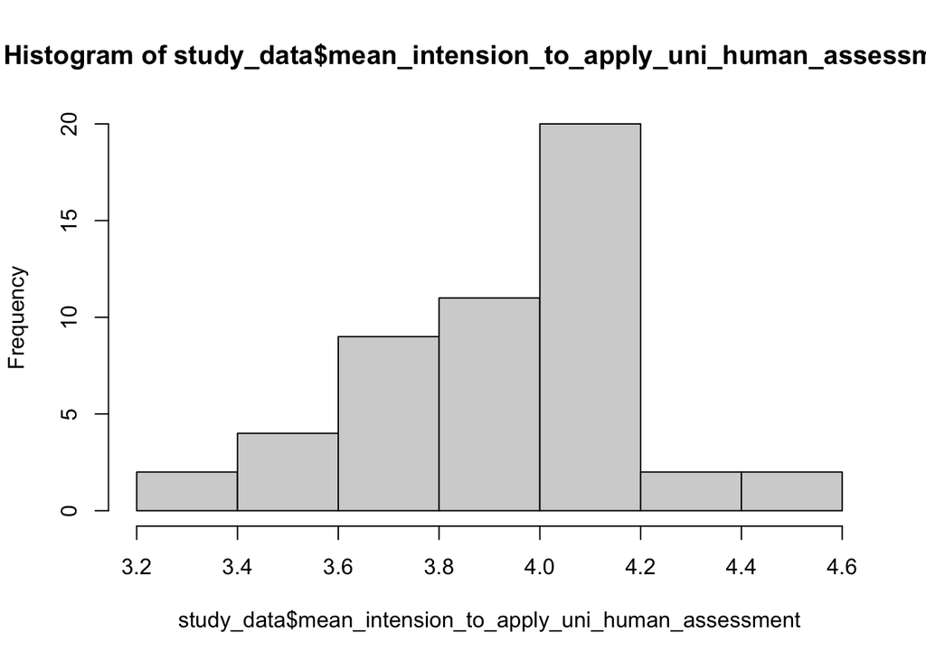

```r
# Histogramm einzelner Variablen ausgeben
# zum Beispiel Attraktivität der Uni 1
# Mittelwert aller Attraktivitätsitems
hist(study_data$mean_intension_to_apply_uni_human_assessment)
```

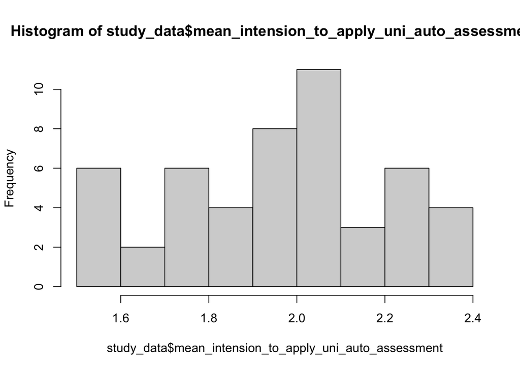

```r
hist(study_data$mean_intension_to_apply_uni_auto_assessment)

# Zentrierung der kontinuierlichen Kovariaten am Gesamtmittelwert zur
# vereinfachten Interpretation, wenn natürlicher Nullpunkt nicht sinnvoll
assessment_data$c_age <- jtools::center(data = assessment_data$age)
```

```r
modality_data$c_age <- jtools::center(data = assessment_data$age)

# Gruppenspezifische (human/auto) Mittelwerte auf dem Outcome (Attraktivität)
library(car)
car::Tapply(intension ~ human_auto, data = assessment_data, fun = mean)
```

```
## human  auto
## 3.986 2.008
```

```r
# Alle gruppenspezifischen Mittelwerte kontrollieren, ob große Mittelwertsunterschiede vorliegen
#library(psych)
psych::describeBy(assessment_data, group = assessment_data$human_auto)
```

```
##
##  Descriptive statistics by group
## group: human
##                                                 vars  n  mean    sd median
## id                                                 1 50 25.50 14.58  25.50
## intension_to_apply_uni_a                           2 50  1.96  0.37   2.00
## attraction_uni_a                                   3 50  1.98  0.23   1.90
## intension_to_apply_uni_b                           4 50  4.02  0.39   4.00
## attraction_uni_b                                   5 50  4.11  0.25   4.10
## intension_to_apply_uni_c                           6 50  2.06  0.36   2.00
## attraction_uni_c                                   7 50  1.94  0.26   2.00
## intension_to_apply_uni_d                           8 50  3.95  0.35   4.00
## attraction_uni_d                                   9 50  4.05  0.27   4.05
## mean_intension_to_apply_uni_flexible_assessment   10 50  2.95  0.21   3.00
## mean_intension_to_apply_uni_fixed_assessment      11 50  3.04  0.27   3.00
## mean_attraction_uni_flexible_assessment           12 50  1.98  0.23   1.90
## mean_attraction_uni_fixed_assessment              13 50  4.11  0.25   4.10
## technical_affinity1                               14 50  1.96  0.37   2.00
## technical_affinity2                               15 50  2.04  0.40   2.00
## mean_technical_affinity                           16 50  2.00  0.25   1.99
## age                                               17 50 25.90  5.13  25.50
## gender*                                           18 50  2.34  0.98   2.00
## course_of_study*                                  19 50  1.00  0.00   1.00
## human_auto*                                       20 50  1.00  0.00   1.00
## intension                                         21 50  3.99  0.28   4.00
## attraction                                        22 50  4.11  0.25   4.10
## c_age                                             23 50  0.00  5.13  -0.40
##                                                 trimmed   mad   min   max range
## id                                                25.50 18.53  1.00 50.00  49.0
## intension_to_apply_uni_a                           1.97  0.30  1.20  2.60   1.4
## attraction_uni_a                                   1.98  0.15  1.50  2.50   1.0
## intension_to_apply_uni_b                           4.02  0.44  3.20  5.00   1.8
## attraction_uni_b                                   4.12  0.30  3.40  4.50   1.1
## intension_to_apply_uni_c                           2.05  0.44  1.20  2.80   1.6
## attraction_uni_c                                   1.96  0.30  1.20  2.40   1.2
## intension_to_apply_uni_d                           3.94  0.30  3.00  4.80   1.8
## attraction_uni_d                                   4.04  0.30  3.50  4.80   1.3
## mean_intension_to_apply_uni_flexible_assessment    2.96  0.15  2.40  3.30   0.9
## mean_intension_to_apply_uni_fixed_assessment       3.04  0.30  2.50  3.60   1.1
## mean_attraction_uni_flexible_assessment            1.98  0.15  1.50  2.50   1.0
```

[output cut: 94 more lines]

```
## attraction_uni_d                                 0.35    -0.26 0.04
## mean_intension_to_apply_uni_flexible_assessment -0.52     0.19 0.03
## mean_intension_to_apply_uni_fixed_assessment     0.15    -0.68 0.04
## mean_attraction_uni_flexible_assessment          0.16     0.14 0.03
## mean_attraction_uni_fixed_assessment            -0.52    -0.25 0.04
## technical_affinity1                              0.49    -0.52 0.05
## technical_affinity2                              0.01    -0.86 0.06
## mean_technical_affinity                          0.36    -0.42 0.03
## age                                              0.13    -1.25 0.73
## gender*                                          0.31    -0.95 0.14
## course_of_study*                                  NaN      NaN 0.00
## human_auto*                                       NaN      NaN 0.00
## intension                                       -0.23    -0.87 0.03
## attraction                                       0.16     0.14 0.03
## c_age                                            0.13    -1.25 0.73
```

## 2.1 Hypothesentest H1: Haupteffekt der UV1

Menschliche Prüfungsauswertung (human) im Vergleich zu algorithmischer Auswertung (automatisiert) führt zu höherer

- 1. Bewerbungsabsicht

```r
library(EffectLiteR)
# - klassische ANCOVA
# - dichotome nominale UV: Prüfungsauswertung (human = 0; auto = 1)
# - dichotome Kovariate: Prüfungsmodalität (flexibel = 0; fixed = 1)
# - ordinale kategoriale Kovariate: Alter (18 - 99)
# - nominale Kovariate: Geschlecht (weiblich = 1; männlich = 2; andere = 3; kA = 4)
# - nominale Kovariate: Studiengang (1 - 12)
# - ordinale kategoriale AV: intention to apply (1 = strongly agree; 6 = strongly disagree)
# - Dummykodierung: Bedingung 3 & 4 = 2 (human); Bedingungen 1 & 2 = 1 (auto)
#
# ⇒ statistische Frage: weicht die mittlere Bewerbungsabsicht von Universitäten mit menschlicher Auswertung von maschineller Auswertung ab?

h1a_model <- effectLite(y = "intension", # AV
                 x = "human_auto", # Treatmentvariable
                 control = "auto", # Kodierung der Kontrollgruppe
                 k = c( "gender", "course_of_study"),
                 z = c("attraction", "c_age"),
                 data = assessment_data,
                 interactions = "none" # Interaktion zwischen Kovariaten zulassen, jedoch nicht zwischen Kovariate und treatmentvariable
                 )

print(h1a_model)
```

```
##
##
## --------------------- Message  ---------------------
##
##  -- model converged succesfully --
##
##
## --------------------- Variables  ---------------------
##
## Outcome variable Y:  intension
## Treatment variable X:  human_auto   (Reference group:  auto)
## Categorical covariates K:  gender course_of_study
## Continuous covariates in Z=(Z1,Z2): Z1=attraction Z2=c_age
##
## Levels of Treatment Variable X
##    X   human_auto (original)   Indicator
##    0                    auto       I_X=0
##    1                   human       I_X=1
##
## Levels of Unfolded Categorical Covariate K
##    K   gender   course_of_study   Indicator
##    0        1                 2       I_K=0
##    1        2                 2       I_K=1
##    2        3                 2       I_K=2
##    3        4                 2       I_K=3
##
## Cells
##     human_auto (original)   K   Cell
## 1                    auto   0     00
## 2                    auto   1     01
## 3                    auto   2     02
## 4                    auto   3     03
## 5                   human   0     10
## 6                   human   1     11
## 7                   human   2     12
## 8                   human   3     13
##
##
##  --------------------- Regression Model ---------------------
##
```

[output cut: 110 more lines]

```
## E[g1(K,Z)|X=1, K=3]        2.1   0.225      9.36         0           8.7
##
##
## --------------------- Hypotheses given K=k ---------------------
##
## H0: No average effects given K=0: E[g1(K,Z)|K=0] = 0
## H0: No average effects given K=1: E[g1(K,Z)|K=1] = 0
## H0: No average effects given K=2: E[g1(K,Z)|K=2] = 0
## H0: No average effects given K=3: E[g1(K,Z)|K=3] = 0
##
##                                Wald Chi-Square   df   p-value
## No average effects given K=0              87.6    1         0
## No average effects given K=1              87.6    1         0
## No average effects given K=2              87.6    1         0
## No average effects given K=3              87.6    1         0
```

- 2. wahrgenommener Attraktivität der Universität.
- “”
- ordinale AV: universitarial attractiveness (1 = strongly agree; 6 = strongly disagree)
- ⇒ statistische Frage: weicht die mittlere Attraktivität von Universitäten mit menschlicher Auswertung von maschineller Auswertung ab?

```r
h1b_model <- effectLite(y = "attraction", # AV
                 x = "human_auto", # Treatmentvariable
                 control = "auto", # Kodierung der Kontrollgruppe
                 k = c( "gender", "course_of_study"),
                 z = c("intension", "c_age"),
                 data = assessment_data,
                 interactions = "none" # Interaktion zwischen Kovariaten zulassen, jedoch nicht zwischen Kovariate und treatmentvariable
                 )

print(h1b_model)
```

```
##
##
## --------------------- Message  ---------------------
##
##  -- model converged succesfully --
##
##
## --------------------- Variables  ---------------------
##
## Outcome variable Y:  attraction
## Treatment variable X:  human_auto   (Reference group:  auto)
## Categorical covariates K:  gender course_of_study
## Continuous covariates in Z=(Z1,Z2): Z1=intension Z2=c_age
##
## Levels of Treatment Variable X
##    X   human_auto (original)   Indicator
##    0                    auto       I_X=0
##    1                   human       I_X=1
##
## Levels of Unfolded Categorical Covariate K
##    K   gender   course_of_study   Indicator
##    0        1                 2       I_K=0
##    1        2                 2       I_K=1
##    2        3                 2       I_K=2
##    3        4                 2       I_K=3
##
## Cells
##     human_auto (original)   K   Cell
## 1                    auto   0     00
## 2                    auto   1     01
## 3                    auto   2     02
## 4                    auto   3     03
## 5                   human   0     10
## 6                   human   1     11
## 7                   human   2     12
## 8                   human   3     13
##
##
##  --------------------- Regression Model ---------------------
##
```

[output cut: 110 more lines]

```
## E[g1(K,Z)|X=1, K=3]       2.22   0.169      13.2         0          10.1
##
##
## --------------------- Hypotheses given K=k ---------------------
##
## H0: No average effects given K=0: E[g1(K,Z)|K=0] = 0
## H0: No average effects given K=1: E[g1(K,Z)|K=1] = 0
## H0: No average effects given K=2: E[g1(K,Z)|K=2] = 0
## H0: No average effects given K=3: E[g1(K,Z)|K=3] = 0
##
##                                Wald Chi-Square   df   p-value
## No average effects given K=0               174    1         0
## No average effects given K=1               174    1         0
## No average effects given K=2               174    1         0
## No average effects given K=3               174    1         0
```

## 2.2 Hypothesentest H2: Haupteffekt der UV2

Flexible Prüfungsabnahme (in Zeit & Ort) im Vergleich zu unflexibler Prüfungsabnahme führt zu höherer

- 1. Bewerbungsabsicht

```r
# - klassische ANCOVA
# - dichotome nominale UV: Prüfungsmodalität (flexibel = 0; fixed = 1)
# - dichotome Kovariate: Prüfungsauswertung (human = 0; auto = 1)
# - ordinale kategoriale Kovariate: Alter (18 - 99)
# - nominale Kovariate: Geschlecht (weiblich = 1; männlich = 2; andere = 3; kA = 4)
# - nominale Kovariate: Studiengang (1 - 12)
# - ordinale kategoriale AV: intention to apply (1 = strongly agree; 6 = strongly disagree)
# - Dummykodierung: Bedingung 1 & 3 = 2 (flexibel); Bedingungen 2 & 4 = 1 (fix)
#
# ⇒ statistische Frage: weicht die mittlere Bewerbungsabsicht von Universitäten mit flexibler orts- & zeitabhängiger Prüfungsabnahme von flexibler ab?

h2a_model <- effectLite(y = "intension", # AV
                 x = "flexible_fixed", # Treatmentvariable
                 control = "fixed", # Kodierung der Kontrollgruppe
                 k = c( "gender", "course_of_study"),
                 z = c("attraction", "c_age"),
                 data = modality_data,
                 interactions = "none" # Interaktion zwischen Kovariaten zulassen, jedoch nicht zwischen Kovariate und treatmentvariable
                 )

print(h2a_model)
```

```
##
##
## --------------------- Message  ---------------------
##
##  -- model converged succesfully --
##
##
## --------------------- Variables  ---------------------
##
## Outcome variable Y:  intension
## Treatment variable X:  flexible_fixed   (Reference group:  fixed)
## Categorical covariates K:  gender course_of_study
## Continuous covariates in Z=(Z1,Z2): Z1=attraction Z2=c_age
##
## Levels of Treatment Variable X
##    X   flexible_fixed (original)   Indicator
##    0                       fixed       I_X=0
##    1                    flexible       I_X=1
##
## Levels of Unfolded Categorical Covariate K
##    K   gender   course_of_study   Indicator
##    0        1                 2       I_K=0
##    1        2                 2       I_K=1
##    2        3                 2       I_K=2
##    3        4                 2       I_K=3
##
## Cells
##     flexible_fixed (original)   K   Cell
## 1                       fixed   0     00
## 2                       fixed   1     01
## 3                       fixed   2     02
## 4                       fixed   3     03
## 5                    flexible   0     10
## 6                    flexible   1     11
## 7                    flexible   2     12
## 8                    flexible   3     13
##
##
##  --------------------- Regression Model ---------------------
##
```

[output cut: 110 more lines]

```
## E[g1(K,Z)|X=1, K=3]      -0.28   0.19     -1.48     0.139         -1.02
##
##
## --------------------- Hypotheses given K=k ---------------------
##
## H0: No average effects given K=0: E[g1(K,Z)|K=0] = 0
## H0: No average effects given K=1: E[g1(K,Z)|K=1] = 0
## H0: No average effects given K=2: E[g1(K,Z)|K=2] = 0
## H0: No average effects given K=3: E[g1(K,Z)|K=3] = 0
##
##                                Wald Chi-Square   df   p-value
## No average effects given K=0              2.19    1     0.139
## No average effects given K=1              2.19    1     0.139
## No average effects given K=2              2.19    1     0.139
## No average effects given K=3              2.19    1     0.139
```

- 2. wahrgenommener Attraktivität der Universität.

```r
# - “”
# - ordinale kategoriale AV: universitarial attractiveness (1 = strongly agree; 6 = strongly disagree)
# ⇒ statistische Frage: weicht die mittlere Attraktivität von Universitäten mit flexibler orts- & zeitabhängiger Prüfungsabnahme von flexibler ab?

h2b_model <- effectLite(y = "attraction", # AV
                 x = "flexible_fixed", # Treatmentvariable
                 control = "fixed", # Kodierung der Kontrollgruppe
                 k = c( "gender", "course_of_study"),
                 z = c("intension", "c_age"),
                 data = modality_data,
                 interactions = "none" # Interaktion zwischen Kovariaten zulassen, jedoch nicht zwischen Kovariate und treatmentvariable
                 )

print(h2b_model)
```

```
##
##
## --------------------- Message  ---------------------
##
##  -- model converged succesfully --
##
##
## --------------------- Variables  ---------------------
##
## Outcome variable Y:  attraction
## Treatment variable X:  flexible_fixed   (Reference group:  fixed)
## Categorical covariates K:  gender course_of_study
## Continuous covariates in Z=(Z1,Z2): Z1=intension Z2=c_age
##
## Levels of Treatment Variable X
##    X   flexible_fixed (original)   Indicator
##    0                       fixed       I_X=0
##    1                    flexible       I_X=1
##
## Levels of Unfolded Categorical Covariate K
##    K   gender   course_of_study   Indicator
##    0        1                 2       I_K=0
##    1        2                 2       I_K=1
##    2        3                 2       I_K=2
##    3        4                 2       I_K=3
##
## Cells
##     flexible_fixed (original)   K   Cell
## 1                       fixed   0     00
## 2                       fixed   1     01
## 3                       fixed   2     02
## 4                       fixed   3     03
## 5                    flexible   0     10
## 6                    flexible   1     11
## 7                    flexible   2     12
## 8                    flexible   3     13
##
##
##  --------------------- Regression Model ---------------------
##
```

[output cut: 110 more lines]

```
## E[g1(K,Z)|X=1, K=3]      -2.17   0.0417     -52.1         0          -8.4
##
##
## --------------------- Hypotheses given K=k ---------------------
##
## H0: No average effects given K=0: E[g1(K,Z)|K=0] = 0
## H0: No average effects given K=1: E[g1(K,Z)|K=1] = 0
## H0: No average effects given K=2: E[g1(K,Z)|K=2] = 0
## H0: No average effects given K=3: E[g1(K,Z)|K=3] = 0
##
##                                Wald Chi-Square   df   p-value
## No average effects given K=0              2717    1         0
## No average effects given K=1              2717    1         0
## No average effects given K=2              2717    1         0
## No average effects given K=3              2717    1         0
```

## 2.3 Hypothesentest H3: Moderation

Bei Personen mit hoch ausgeprägter technischer Affinität ist der Effekt in der H1 geringer als bei Personen mit niedrig ausgeprägter technischer Affinität

- 1. Bewerbungsabsicht

```r
# - generalisierte ANCOVA
# - dichotome nominalskalierte UV1: Prüfungsmodalität (flexibel = 0; fix = 1)
# - (polytomer) ordinalskalierter Moderator: technische Affinität (not true at all = 1; very true = 5)
# - dichotome Kovariate: Prüfungsmodalität (flexibel = 0; fix = 1)
# - ordinale kategoriale Kovariate: Alter (18 - 99)
# - nominale Kovariate: Geschlecht (weiblich = 1; männlich = 2; andere = 3; kA = 4)
# - nominale Kovariate: Studiengang (1 - 12)
# - ordinale kategoriale AV: intention to apply (1 = strongly agree; 6 = strongly disagree)
# - Dummykodierung: Bedingung 3 & 4 = 2 (human); Bedingungen 1 & 2 = 1 (auto)
#
# ⇒ statistische Frage: ist der Interaktionsterm zwischen der Prüfungsmodalität und technischer Affinität bedeutsam in ihrer Vorhersage der Bewerbungsabsicht?

h3a_model <- effectLite(y = "intension", # AV
                 x = "human_auto", # Treatmentvariable
                 control = "auto", # Kodierung der Kontrollgruppe
                 k = c( "gender", "course_of_study"),
                 z = c("attraction", "c_age", "mean_technical_affinity"),
                 data = assessment_data,
                 interactions = "X:K" # Interaktion zwischen Treatment und Kovariaten zulassen
                 )

print(h3a_model)
```

```
##
##
## --------------------- Message  ---------------------
##
##  -- model converged succesfully --
##
##
## --------------------- Variables  ---------------------
##
## Outcome variable Y:  intension
## Treatment variable X:  human_auto   (Reference group:  auto)
## Categorical covariates K:  gender course_of_study
## Continuous covariates in Z=(Z1,Z2,Z3): Z1=attraction Z2=c_age Z3=mean_technical_affinity
##
## Levels of Treatment Variable X
##    X   human_auto (original)   Indicator
##    0                    auto       I_X=0
##    1                   human       I_X=1
##
## Levels of Unfolded Categorical Covariate K
##    K   gender   course_of_study   Indicator
##    0        1                 2       I_K=0
##    1        2                 2       I_K=1
##    2        3                 2       I_K=2
##    3        4                 2       I_K=3
##
## Cells
##     human_auto (original)   K   Cell
## 1                    auto   0     00
## 2                    auto   1     01
## 3                    auto   2     02
## 4                    auto   3     03
## 5                   human   0     10
## 6                   human   1     11
## 7                   human   2     12
## 8                   human   3     13
##
##
##  --------------------- Regression Model ---------------------
##
```

[output cut: 120 more lines]

```
## E[g1(K,Z)|X=1, K=3]       2.23   0.636      3.50   4.66e-04          9.06
##
##
## --------------------- Hypotheses given K=k ---------------------
##
## H0: No average effects given K=0: E[g1(K,Z)|K=0] = 0
## H0: No average effects given K=1: E[g1(K,Z)|K=1] = 0
## H0: No average effects given K=2: E[g1(K,Z)|K=2] = 0
## H0: No average effects given K=3: E[g1(K,Z)|K=3] = 0
##
##                                Wald Chi-Square   df    p-value
## No average effects given K=0              34.5    1   4.29e-09
## No average effects given K=1              28.7    1   8.52e-08
## No average effects given K=2               6.0    1   1.43e-02
## No average effects given K=3              12.2    1   4.66e-04
```

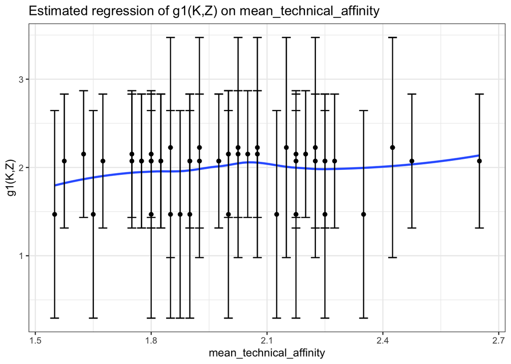

```r
# plot der von bedingten Effekten + SE
# https://rdrr.io/cran/EffectLiteR/src/R/elr_plot_condeffects.R
conditionalEffectsPlot(h3a_model, zsel = "mean_technical_affinity", gxsel = "g1",
                       colour = "", show.ci = TRUE)
```

2. wahrgenommener Attraktivität der Universität.

```r
# - “”
# - ordinale kategoriale AV: universitarial attractiveness (1 = strongly agree; 6 = strongly disagree)
# ⇒ statistische Frage: ist der Interaktionsterm zwischen der Prüfungsmodalität und technischer Affinität bedeutsam in ihrer Vorhersage der Attraktivität der Universität?


h3b_model <- effectLite(y = "attraction", # AV
                 x = "human_auto", # Treatmentvariable
                 control = "auto", # Kodierung der Kontrollgruppe
                 k = c( "gender", "course_of_study"),
                 z = c("intension", "c_age", "mean_technical_affinity"),
                 data = assessment_data,
                 interactions = "X:K" # Interaktion zwischen Treatment und Kovariaten zulassen
                 )

print(h3b_model)
```

```
##
##
## --------------------- Message  ---------------------
##
##  -- model converged succesfully --
##
##
## --------------------- Variables  ---------------------
##
## Outcome variable Y:  attraction
## Treatment variable X:  human_auto   (Reference group:  auto)
## Categorical covariates K:  gender course_of_study
## Continuous covariates in Z=(Z1,Z2,Z3): Z1=intension Z2=c_age Z3=mean_technical_affinity
##
## Levels of Treatment Variable X
##    X   human_auto (original)   Indicator
##    0                    auto       I_X=0
##    1                   human       I_X=1
##
## Levels of Unfolded Categorical Covariate K
##    K   gender   course_of_study   Indicator
##    0        1                 2       I_K=0
##    1        2                 2       I_K=1
##    2        3                 2       I_K=2
##    3        4                 2       I_K=3
##
## Cells
##     human_auto (original)   K   Cell
## 1                    auto   0     00
## 2                    auto   1     01
## 3                    auto   2     02
## 4                    auto   3     03
## 5                   human   0     10
## 6                   human   1     11
## 7                   human   2     12
## 8                   human   3     13
##
##
##  --------------------- Regression Model ---------------------
##
```

[output cut: 120 more lines]

```
## E[g1(K,Z)|X=1, K=3]       2.34   0.327      7.15   8.90e-13         10.41
##
##
## --------------------- Hypotheses given K=k ---------------------
##
## H0: No average effects given K=0: E[g1(K,Z)|K=0] = 0
## H0: No average effects given K=1: E[g1(K,Z)|K=1] = 0
## H0: No average effects given K=2: E[g1(K,Z)|K=2] = 0
## H0: No average effects given K=3: E[g1(K,Z)|K=3] = 0
##
##                                Wald Chi-Square   df    p-value
## No average effects given K=0              15.5    1   8.36e-05
## No average effects given K=1              67.4    1   2.22e-16
## No average effects given K=2              30.0    1   4.33e-08
## No average effects given K=3              51.1    1   8.90e-13
```

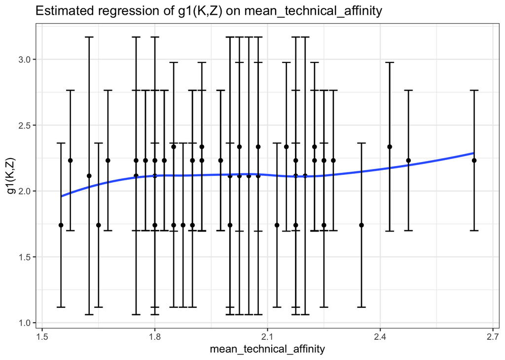

```r
# plot der von bedingten Effekten + SE
# https://rdrr.io/cran/EffectLiteR/src/R/elr_plot_condeffects.R
conditionalEffectsPlot(h3b_model, zsel = "mean_technical_affinity", gxsel = "g1",
                       colour = "", show.ci = TRUE)
```